# Problem Set 5

Author

Janet Wang

Github here: https://github.com/janetjw/STATS506/blob/main/ProblemSets/JW_PS5.qmd https://github.com/janetjw/STATS506/blob/main/ProblemSets/JW_PS5.html

# Question 1

### a

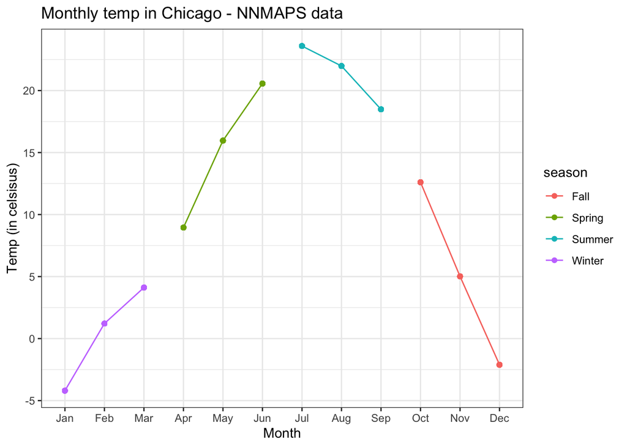

```r
theme_set(theme_bw()) #making the background of the plot white for better contrast
nnmaps <- read.csv("chicago-nmmaps.csv")

nnmaps <- nnmaps %>% #creating the monthly temperature in Celsisus variable
  group_by(month) %>%
  mutate(monthly_temp = mean((temp-32)*5/9))


nnmaps <- nnmaps %>% #creating the season variable
  mutate(season = case_when(
            (month == "Mar"| month =="Jan"|month == "Feb") ~ "Winter",
            (month =="Jun"|month == "Apr"|month =="May") ~ "Spring",
            (month =="Sep"|month == "Jul"|month =="Aug") ~ "Summer",
            (month == "Dec"|month =="Oct"|month == "Nov") ~ "Fall"))

nnmaps$month <- factor(nnmaps$month, levels=c("Jan", "Feb", "Mar", "Apr", "May", "Jun", "Jul", "Aug", "Sep", "Oct", "Nov", "Dec")) #releveling month to begin with December

ggplot(nnmaps, aes(x=month, y=monthly_temp, color = season, group = season)) +
  geom_point() +
  geom_line() +
  labs(title = "Monthly temp in Chicago - NNMAPS data") +
  xlab("Month") +
  ylab("Temp (in celsisus)")
```

### b

I used this websit to get code for different types of lines: http://www.sthda.com/english/wiki/line-types-in-r-lty#:~:text=line%20type%20(lty)%20can%20be,is%20identical%20to%20lty%3D1

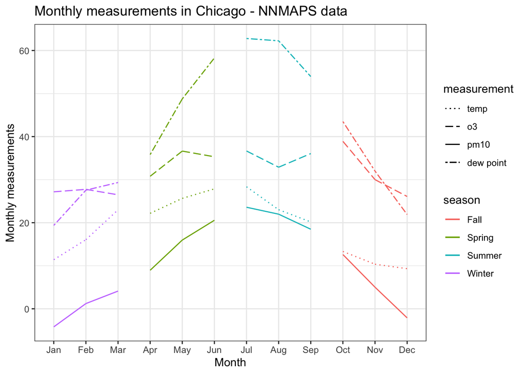

```r
nnmaps <- nnmaps %>% #creating the monthly O3,PM10,dewpoint
  group_by(month) %>%
  mutate(monthly_o3 = mean(o3),
         monthly_pm10 = mean(pm10, na.rm = TRUE),
         monthly_dewpoint = mean(dewpoint))

ggplot(nnmaps, aes(x = month_numeric, color = season, group = season)) +
  geom_line(aes(y=monthly_temp, lty = "solid")) +
  geom_line(aes(y=monthly_o3, lty = "dotted")) +
  geom_line(aes(y=monthly_pm10, lty = "longdash")) +
  geom_line(aes(y=monthly_dewpoint, lty = "twodash")) +
  labs(title = "Monthly measurements in Chicago - NNMAPS data") +
  xlab("Month")+
  ylab("Monthly measurements")+
  scale_x_discrete(limits = unique(nnmaps$month))+
  scale_linetype_manual(name = "measurement",
                        values = c("solid" = "solid",
                                   "dotted" = "dotted",
                                   "longdash" = "longdash",
                                   "twodash" = "twodash"),
                        labels = c("temp", "o3", "pm10", "dew point"))
```

# Question 2

### a

```r
#' @param data vector of numerics for coefficients for the polynomial expression
make_poly <- setClass("Poly",
  slots = c(data = "numeric")
)

#creating the validator (checkign to see if data is a numeric vector of coefs)
setValidity("Poly", function(object) {
  if (is.numeric(object@data) != T | is.vector(object@data) != T) {
    stop("Invalid vector of coefficients! Please enter a numeric vector of coefficients for your polynomial!")
  }
  return(TRUE)
})
```

```
Class "Poly" [in ".GlobalEnv"]

Slots:

Name:     data
Class: numeric
```

```r
#creating show to display the polynomial expression
setMethod("show", "Poly",
          function(object) {
              output <- NULL
              for(i in 0:length(object@data))
                {
                 output[i] = paste(object@data[i], "x^",
                                   length(object@data)-i,
                                   sep= "")
                }
              return((cat(output)))
          })

#set the method for addition
setMethod("+", signature(e1 = "Poly",
                         e2 = "Poly"),
          function(e1, e2) {
                        if(length(e1@data) == length(e2@data))
                        {
                          new_data = e1@data - e2@data
                        }
                       else {
                         newdata <- NULL
                         for(i in 1:((length(e2@data)-length(e1@data)) )){
                           newdata[i]=e2@data[i]
                         }
                         newdata[(i+1):length(e2@data)] <- e1@data + e2@data[(i+1):length(e2@data)]
                         new_data = newdata
                         }
            out <- new("Poly", data = new_data)

            validObject(out)
            return(out)
          })
#set the method for subtraction
setMethod("-", signature(e1 = "Poly",
                         e2 = "Poly"),
          function(e1, e2) {
                        if(length(e1@data) == length(e2@data))
                        {
                          new_data = e1@data - e2@data
                        }
                       else {
                         newdata <- NULL
                         for(i in 1:((length(e2@data)-length(e1@data)) )){
                           newdata[i]=e2@data[i]
                         }
                         newdata[(i+1):length(e2@data)] <- e1@data - e2@data[(i+1):length(e2@data)]
                         new_data = newdata
                         }
            out <- new("Poly", data = new_data)

            validObject(out)
            return(out)
          })
```

### b

```r
p1 <- make_poly(data = c(3, 0, 2))
p2 <- make_poly(data = c(9, -2, -1, 17))
```

```r
p1
```

```
3x^2 0x^1 2x^0
```

```r
p2
```

```
9x^3 -2x^2 -1x^1 17x^0
```

```r
p1 + p2
```

```
9x^3 1x^2 -1x^1 19x^0
```

```r
p1 - p2
```

```
9x^3 5x^2 1x^1 -15x^0
```

# Question 3

### a

Generate a table (which can just be a nicely printed tibble) reporting the mean and median departure delay per airport. Generate a second table (which again can be a nicely printed tibble) reporting the mean and median arrival delay per airport. Exclude any destination with under 10 flights. Do this exclusion through code, not manually.

Additionally, Order both tables in descending mean delay. Both tables should use the airport names not the airport codes. Both tables should print all rows.

```r
library(nycflights13)
data("flights")
data("airports")
library(data.table)
airports <- data.table(airports)
flights <- data.table(flights)
```

```r
flight <- flights[, .(numflights_dest = .N),
                    key = .(dest)]

flights <- flights |>
  merge(x= _, flight,
        by = "dest", all = TRUE)

flights <- flights[numflights_dest >= 10, ]

flight <- flights[, .(mean_delay = mean(dep_delay, na.rm = TRUE),
                    med_delay = median(dep_delay, na.rm = TRUE),
                    numflights = .N),
                    key = .(origin)]
flight
```

```
   origin mean_delay med_delay numflights
1:    EWR   15.10811        -1     120826
2:    JFK   12.11216        -1     111279
3:    LGA   10.34707        -3     104661
```

```r
data("flights")
data("airports")
library(data.table)
airports <- data.table(airports)
flights <- data.table(flights)

### arrival
flights %>%
  rename(faa = dest) %>%
  left_join(airports %>%
              group_by(faa) %>%
              summarise(name = toString(name)), by = 'faa') %>%
  group_by(faa) %>%
  rename(dest = faa) %>%
  filter(n() >= 10) %>%
  ungroup() %>%
  rename(faa = dest) %>%
  group_by(name) %>%
  summarize(mean_delay = mean(arr_delay, na.rm = TRUE),
            median_delay = median(arr_delay, na.rm = TRUE)) %>%
  arrange(-mean_delay)
```

```
# A tibble: 99 × 3
   name                          mean_delay median_delay
   <chr>                              <dbl>        <dbl>
 1 Columbia Metropolitan               41.8           28
 2 Tulsa Intl                          33.7           14
 3 Will Rogers World                   30.6           16
 4 Jackson Hole Airport                28.1           15
 5 Mc Ghee Tyson                       24.1            2
 6 Dane Co Rgnl Truax Fld              20.2            1
 7 Richmond Intl                       20.1            1
 8 Akron Canton Regional Airport       19.7            3
 9 Des Moines Intl                     19.0            0
10 Gerald R Ford Intl                  18.2            1
# ℹ 89 more rows
```

### b

How many flights did the aircraft model with the fastest average speed take? Produce a tibble with 1 row, and entires for the model, average speed (in MPH) and number of flights.

```r
fl<-flights %>%
  left_join(planes %>%
              group_by(tailnum) %>%
              summarise(model = toString(model)), by = 'tailnum')

fl <- fl %>%
  mutate(speed = distance/air_time)
# fl <- fl |>
#   merge(x= _, flo,
#         by = "time_hour", all = TRUE)
fl %>%
  group_by(model) %>%
  summarise(avgspeed = mean(speed, na.rm = T)*60) %>%
  arrange(-avgspeed) %>%
  head(1)
```

```
# A tibble: 1 × 2
  model   avgspeed
  <chr>      <dbl>
1 777-222     483.
```

```r
fl %>%
  filter(model == "777-222") %>%
  group_by(model) %>%
  reframe(avgspeed_mph = mean(speed, na.rm = T)*60,
          number_of_flights = n())
```

```
# A tibble: 1 × 3
  model   avgspeed_mph number_of_flights
  <chr>          <dbl>             <int>
1 777-222         483.                 4
```